# CS5801 Coursework Template Proforma

## 3.2 Build a model for property price

Before proceeding with the modeling, the data is going to be split into train-test sets. This is a good machine learning practice, as it helps avoiding overfitting of the model. Since we are not using advanced machine learning algorithms, the train-test set will be helpful to determine the most significant coefficients in the train set, to later check the model summary in the test set.

```r
#The train-tes sets are sampled, being 80% of the data set used for training
set.seed(1)
row.number <- sample(1:nrow(df), 0.8*nrow(df))
train = df[row.number,]
test = df[-row.number,]
dim(train)
```

```
## [1] 723  11
```

```r
dim(test)
```

```
## [1] 181  11
```

Now, the maximal model can be built:

```r
df.lm<-lm(price~sqm + floor + rooms +bathrooms + terrace + alarm + heating + ac + parking + furnished, data = train)
summary(df.lm)
```

```
##
## Call:
## lm(formula = price ~ sqm + floor + rooms + bathrooms + terrace +
##     alarm + heating + ac + parking + furnished, data = train)
##
## Residuals:
##     Min      1Q  Median      3Q     Max
## -216040  -56192  -16370   38842  318451
##
## Coefficients:
##               Estimate Std. Error t value Pr(>|t|)
## (Intercept)  -20318.40   86198.99  -0.236  0.81372
## sqm             269.32      53.52   5.032 6.16e-07 ***
## floor2         4537.28    7385.28   0.614  0.53917
## floor3        -2251.65    9956.67  -0.226  0.82115
## floor4         8968.41   16850.57   0.532  0.59473
## floor5       -12129.95   22942.64  -0.529  0.59718
## floor6        61928.79   43657.95   1.418  0.15649
## floor7       -12440.36   61716.35  -0.202  0.84031
## rooms2        77826.85   86472.40   0.900  0.36842
## rooms3       108335.90   86279.79   1.256  0.20967
## rooms4       109310.29   86391.43   1.265  0.20619
## rooms5       102889.87   86528.30   1.189  0.23481
## bathrooms2    46407.76    7391.94   6.278 6.00e-10 ***
## bathrooms3    74100.45   17868.77   4.147 3.78e-05 ***
## terrace1      30133.09    9718.13   3.101  0.00201 **
## alarm1        38298.08   43520.05   0.880  0.37915
## heatingother  14325.94   10829.96   1.323  0.18633
## ac1            9367.06    7118.96   1.316  0.18867
## parking1     -25568.00   33146.47  -0.771  0.44075
## furnished1    13391.06   12716.46   1.053  0.29268
## ---
## Signif. codes:  0 '***' 0.001 '**' 0.01 '*' 0.05 '.' 0.1 ' ' 1
##
## Residual standard error: 85960 on 703 degrees of freedom
## Multiple R-squared:  0.2131, Adjusted R-squared:  0.1918
## F-statistic: 10.02 on 19 and 703 DF,  p-value: < 2.2e-16
```

The model’s performance does not look very promising. Although the F-statistic is significant (as it is greater than 1), the r-squared is still very low (0.19), thus it does not do a good job explaining the model’s variance.

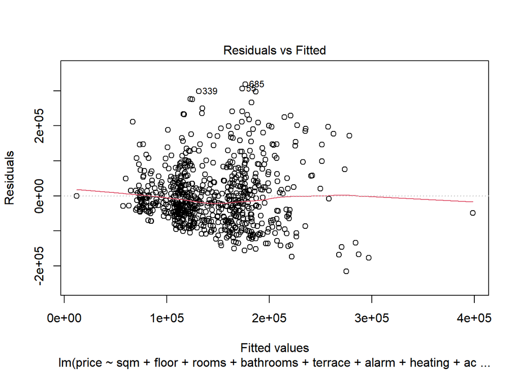

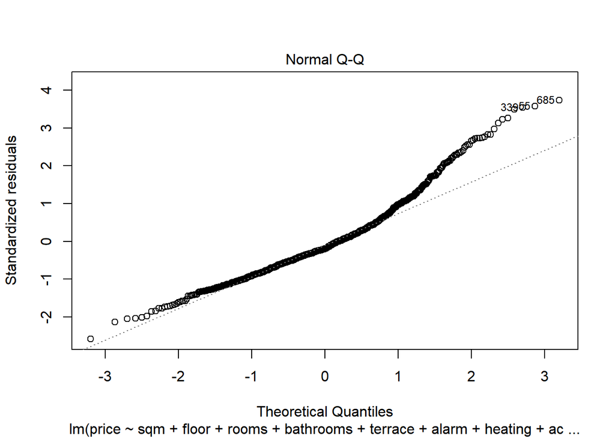

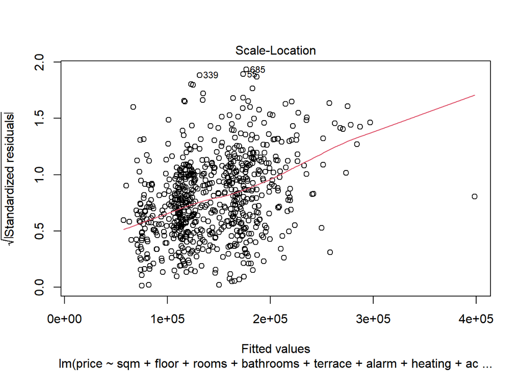

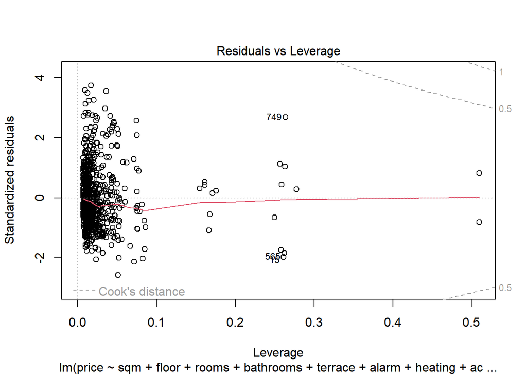

```r
plot(df.lm)
```

Only “sqm”, “bathrooms”, and “terrace” are significant. Moreover, exploring the residual plots, we can see in the first one how the variance of the residuals increases with the mean, in other words, heteroskedasticity occurs. This can lead to more problems and less accurate models, so one way of fixing this is applying a log transformation to the dependent variable “price” (this is possible as there can not be negative or null values for the price). Moreover, as “sqm” is a squared measurement, a transformation is going to be applied to this term. This way, we can start over the whole process:

```r
df.lm2<-lm(log(price)~sqm + I(sqrt(sqm)) + floor + rooms +bathrooms + terrace + alarm + heating + ac + parking + furnished, data = train)
summary(df.lm2)
```

```
##
## Call:
## lm(formula = log(price) ~ sqm + I(sqrt(sqm)) + floor + rooms +
##     bathrooms + terrace + alarm + heating + ac + parking + furnished,
##     data = train)
##
## Residuals:
##      Min       1Q   Median       3Q      Max
## -2.27066 -0.38661  0.05301  0.43082  1.45965
##
## Coefficients:
##               Estimate Std. Error t value Pr(>|t|)
## (Intercept)   8.208505   0.695352  11.805  < 2e-16 ***
## sqm          -0.003113   0.001530  -2.034 0.042292 *
## I(sqrt(sqm))  0.142198   0.043923   3.237 0.001263 **
## floor2        0.052213   0.053748   0.971 0.331665
## floor3       -0.032401   0.072262  -0.448 0.654015
## floor4        0.080056   0.122408   0.654 0.513316
## floor5       -0.111388   0.166566  -0.669 0.503888
## floor6        0.160072   0.317287   0.505 0.614067
## floor7        0.068253   0.447917   0.152 0.878932
## rooms2        1.959376   0.629322   3.113 0.001924 **
## rooms3        2.227664   0.626604   3.555 0.000403 ***
## rooms4        2.185480   0.627050   3.485 0.000522 ***
## rooms5        2.102006   0.627997   3.347 0.000860 ***
## bathrooms2    0.255341   0.054582   4.678 3.47e-06 ***
## bathrooms3    0.363211   0.131226   2.768 0.005792 **
## terrace1      0.282250   0.070566   4.000 7.01e-05 ***
## alarm1        0.270455   0.315910   0.856 0.392226
## heatingother  0.076648   0.078735   0.973 0.330648
## ac1           0.034237   0.051670   0.663 0.507798
## parking1     -0.204607   0.240564  -0.851 0.395321
## furnished1    0.019817   0.092476   0.214 0.830379
## ---
## Signif. codes:  0 '***' 0.001 '**' 0.01 '*' 0.05 '.' 0.1 ' ' 1
##
## Residual standard error: 0.6239 on 702 degrees of freedom
## Multiple R-squared:  0.2235, Adjusted R-squared:  0.2014
## F-statistic: 10.11 on 20 and 702 DF,  p-value: < 2.2e-16
```

In terms of performance, the transformations have not helped much.